# Lab8: R Notebook

## Introduction to JAGS

- JAGS is “Just Another Gibbs Sampler”,
- High level scripting language for automatic MCMC for Bayesian models
- to run on your own machine, you will need to install jags locally (see computing resources on website for links)
- to use JAGS we need to specify
  - data & fixed parameters
  - model (sampling model + prior distributions)
  - starting values (optional)
  - parameters to save
  - options for running the MCMC

## Model specification

JAGS lets you write out the distributions using a syntax that is similar to R’s functions. This can be written in R and then passed onto JAGS.

Let’s define a function for the Bayesian Ridge Regression Model

```r
rr.model = function() {
  for (i in 1:n) {
      mu[i] <- inprod(X[i,], beta.s)  + alpha0
      # alpha are parameters in scaled model
      Y[i] ~ dnorm(mu[i], phi)
  }
  phi ~ dgamma(1.0E-6, 1.0E-6)  # approximate p(phi) = 1/phi
  alpha0  ~ dnorm(0, 1.0E-10)  # approximate p(alpha_0) = 1

  for (j in 1:p) {
      prec.beta[j] <- lambda.beta*phi
      beta.s[j] ~ dnorm(0, prec.beta[j])
  }
# Cauchy Prior on beta
  lambda.beta ~ dgamma(.5, .5)
  for (j in 1:p) {
      beta[j] <- beta.s[j]/scales[j]   # rescale
  }
  # transform intercept to original units (uncenter)
  beta0 <- alpha0 - inprod(beta, Xbar)
  sigma <- pow(phi, -.5)
}
```

This function assumes that the design matrix has been scaled and centered ahead of time. This is computationally more efficient as a one time calculation rather than doing it within the JAGS code.

- Stochastic nodes
- deterministic nodes
- assignment needs to use `<-` rahter than `=` (not really `R`)

## Data

All quantities that are in the function need to be either generated (stochastic) or calculated (deterministic) in the function or available through the data passed to JAGS.

For say the college data:

```r
library(ISLR)
data(College)
# JAGS needs a matrix not a dataframe
X = model.matrix(sqrt(Apps) ~ ., data=College)
X = X[,-1]  # drop intercept
# Create a data list with inputs for WinBugs
scaled.X = scale(X)
data = list(Y = sqrt(College$Apps),   # variance stabilizing transformation
            X=cbind(scaled.X), p=ncol(X))
data$n = length(data$Y)
data$scales = c(1, attr(scaled.X, "scaled:scale"))
data$Xbar = attr(scaled.X, "scaled:center")
```

## Parameters

we can save any of the stochastic or deterministic nodes

```r
parameters = c("beta.s", "beta", "beta0", "lambda.beta", "sigma")
```

## Running JAGS

We will run JAGS through R using functions in the R2jags package.

```r
library(R2jags)
rr.sim = jags(data, inits=NULL,
              parameters.to.save=parameters,
              model.file=rr.model,
              n.iter=10000)
```

[output not shown]

```r
theta = as.mcmc(rr.sim$BUGSoutput$sims.matrix)  # create an MCMC object
```

You should see a progress bar as this runs

## Output

Let’s look at the output: the summary function just tells us the names of objects and their size/type

```r
summary(rr.sim)
```

```
                   Length Class  Mode
model               8     jags   list
BUGSoutput         24     bugs   list
parameters.to.save  6     -none- character
model.file          1     -none- character
n.iter              1     -none- numeric
DIC                 1     -none- logical
```

Plots and basic diagnostics

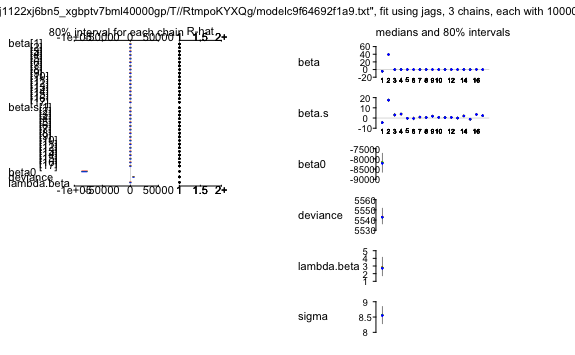

```r
plot(rr.sim)
```

```r
print(rr.sim)
```

```
Inference for Bugs model at "/var/folders/n4/nj1122xj6bn5_xgbptv7bml40000gp/T//RtmpoKYXQg/modelc9f64692f1a9.txt", fit using jags,
 3 chains, each with 10000 iterations (first 5000 discarded), n.thin = 5
 n.sims = 3000 iterations saved
               mu.vect  sd.vect       2.5%        25%        50%
beta[1]         -4.539    0.504     -5.512     -4.867     -4.531
beta[2]         39.288    1.880     35.662     38.108     39.282
beta[3]          0.001    0.001      0.000      0.001      0.001
beta[4]          0.004    0.001      0.003      0.004      0.004
beta[5]         -0.017    0.041     -0.097     -0.043     -0.017
beta[6]         -0.020    0.065     -0.141     -0.065     -0.020
beta[7]          0.000    0.000      0.000      0.000      0.000
beta[8]          0.000    0.000      0.000      0.000      0.000
beta[9]          0.000    0.000      0.000      0.000      0.000
beta[10]         0.001    0.000      0.000      0.000      0.001
beta[11]         0.003    0.002     -0.001      0.001      0.003
beta[12]         0.001    0.001     -0.001      0.000      0.001
beta[13]         0.000    0.038     -0.072     -0.025     -0.001
beta[14]         0.138    0.030      0.081      0.119      0.137
beta[15]        -0.298    0.108     -0.517     -0.366     -0.296
beta[16]         0.281    0.042      0.198      0.252      0.281
beta[17]         0.000    0.000      0.000      0.000      0.000
beta.s[1]       -4.539    0.504     -5.512     -4.867     -4.531
beta.s[2]       17.511    0.838     15.895     16.985     17.508
beta.s[3]        3.048    1.341      0.456      2.162      3.050
beta.s[4]        3.899    0.791      2.352      3.386      3.905
beta.s[5]       -0.299    0.719     -1.712     -0.765     -0.302
beta.s[6]       -0.395    1.292     -2.799     -1.294     -0.397
beta.s[7]        0.920    0.407      0.163      0.650      0.920
beta.s[8]        0.511    0.654     -0.724      0.101      0.515
beta.s[9]        1.804    0.457      0.955      1.505      1.795
beta.s[10]       0.634    0.332     -0.027      0.413      0.643
beta.s[11]       0.452    0.373     -0.223      0.210      0.442
beta.s[12]       0.561    0.619     -0.706      0.162      0.571
beta.s[13]      -0.003    0.621     -1.180     -0.411     -0.010
beta.s[14]       2.028    0.444      1.200      1.747      2.019
beta.s[15]      -1.178    0.428     -2.045     -1.448     -1.171
beta.s[16]       3.477    0.525      2.459      3.118      3.484
beta.s[17]       2.357    0.437      1.537      2.065      2.359
beta0       -81904.575 3801.799 -89105.006 -84371.624 -81875.636
lambda.beta      2.862    1.029      1.299      2.155      2.761
```

[output cut: 33 more lines]

```
beta.s[14]       2.313      2.859 1.003  3000
beta.s[15]      -0.900     -0.383 1.001  3000
beta.s[16]       3.840      4.502 1.001  3000
beta.s[17]       2.649      3.192 1.002  3000
beta0       -79509.242 -74487.305 1.003   980
lambda.beta      3.436      5.039 1.002  1200
sigma            8.710      9.017 1.001  3000
deviance      5547.101   5557.485 1.001  3000

For each parameter, n.eff is a crude measure of effective sample size,
and Rhat is the potential scale reduction factor (at convergence, Rhat=1).

DIC info (using the rule, pD = var(deviance)/2)
pD = 2371.8 and DIC = 7917.4
DIC is an estimate of expected predictive error (lower deviance is better).
```

Compare to Ridge Regression:

```r
library(MASS)
college.ridge = lm.ridge(sqrt(Apps) ~ ., data=College, lambda=seq(0, 10, length=50))
select(college.ridge)
```

```
modified HKB estimator is 2.789363
modified L-W estimator is 1.624918
smallest value of GCV  at 3.061224
```

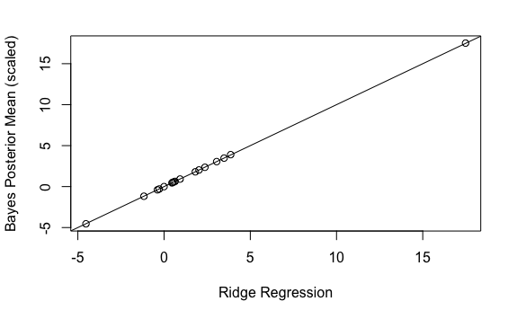

```r
best = which.min(college.ridge$GCV)
best.rr = lm.ridge(sqrt(Apps) ~ ., data=College,
                   lambda=college.ridge$lambda[best])
bayes.rr = rr.sim$BUGSoutput$summary
beta.s = bayes.rr[grep("beta.s", rownames(bayes.rr)), "mean" ]
beta = bayes.rr[grep("beta\\[", rownames(bayes.rr)), "mean" ]
plot(best.rr$coef, beta.s, xlab="Ridge Regression", ylab="Bayes Posterior Mean (scaled)")
abline(0,1)
```

## HPD Intervals and Posterior Density for Lambda

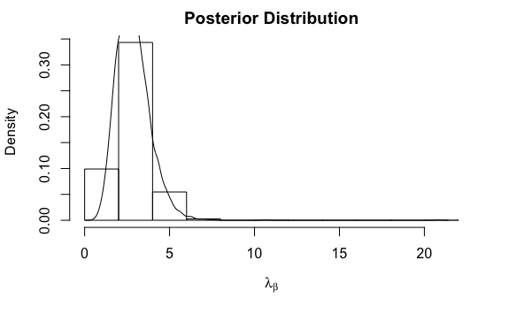

```r
hist(theta[,"lambda.beta"], prob=T, xlab=expression(lambda[beta]),
     main="Posterior Distribution")
lines(density(theta[,"lambda.beta"]))
```

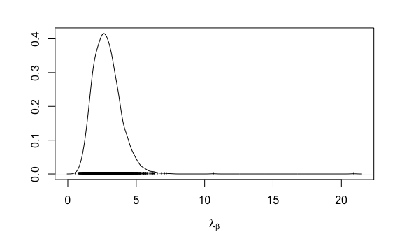

```r
densplot(theta[,"lambda.beta"], xlab =expression(lambda[beta]) )
```

```r
HPDinterval(as.mcmc(theta[,"lambda.beta"]))
```

```
        lower    upper
var1 1.181685 4.816107
attr(,"Probability")
[1] 0.95
```

How does the GCV estimate of $\lambda$ compare to the posterior mean? or where does it fall in the distribution?

## To Do or think about

1. How would you implement a predictive check for ridge regression (frequentist or Bayesian)?
2. Explore out of sample errors or coverage? How does this compare to your earlier results?
3. What about other model diagnostics?
4. Look around at R packages that implement Ridge regression. How many provide uncertainty estimates associated with the $\beta$s or predictions?